# Data Preparation for Modelling

Mena WANG

2021-06-20

# 1 Project Overview

The purpose of this report is **to investigate the effects of vaccines on two key aspects of the pandemic**:

- 1. slowing down the **spread** and
- 2. reducing the **severity of illness** from Covid-19

The analysis was done using the **many-models approach**, where the same model was estimated among each and every entity with data then summarized to gain a comprehensive picture of vaccine effectiveness worldwide.

**The full report is too big for GitHub to host, you can find it [here](https://rpubs.com/MenaWANG/COVID19Vaccines), or explore it through this [interactive dashboard](https://rstudioconnect-online.monash.edu/connect/#/apps/287/access).** Followed is the code used to prepare data for the many-models analysis. You can also download the prepared data from the [Data Folder](https://github.com/MenaWANG/Covid19VaccineData).

Have fun wrangling and analyzing the data! Comments and suggestions highly appreciated, thanks!

# 2 Data Overview

One of the best COVID-19 datasets is the daily-updated Covid-19 dataset offered by [Our World in Data](https://ourworldindata.org/coronavirus). Still, some wrangling needs to be done before the data will be ready for modeling.

For those interested in the wrangling process, please read ahead; for those who simply want to use the prepared the data, here is a list of data you can find in the **[Data Folder](https://github.com/MenaWANG/Covid19VaccineData)**:

1. **VacccineAllVariables.csv**: Dataset with imputed vaccine numbers, smoothed case and deaths numbers, and a comprehensive list of other relevant variables.
2. **Vaccine.RDS**: Dataset with only the key variables in RDS format, used in deploying [this Dashboard](https://rstudioconnect-online.monash.edu/connect/#/apps/287/access) to boost performance.
3. **Entity.RDS**: List of all entities in the original dataset, categorized as included vs not-included in the analysis depending on its population. The population threshold is now set as 100K (i.e., only entities with population larger than 100K are included), you can adjust the value in the following code chunk, the above two data files will change accordingly.
4. **BasicInfo.RDS**: Document basic information including the population bar, last updated date, etc for reference.

```r
#Download the dataset
df <- read_csv(file = 'https://covid.ourworldindata.org/data/owid-covid-data.csv')

#Record the time when the data was downloaded
Now=Sys.time()

#Save this time for use as subtitle in graphs
Subtitle=glue::glue("Last Updated {Now}")

#Safe all basic information about the dataset in one place for future use and reference
BasicInfo<-tibble(LastUpdate=format(Sys.Date(),"%d %b, %Y"), #Document the updated date
                  ncol=ncol(df)) #Document the number of variables in the original dataset



#Adjust variable type and filter out collectives (world,continents) in location
all <-df %>%
    mutate(Continent=as.factor(continent),
           Date=as.Date(date)) %>%
    filter(!location %in% c("World","International"),
           !location %in% c("Asia","Africa","Europe","North America","Oceania","South America")
           ) %>%
    rename(Population=population,
           GDP_per_capita=gdp_per_capita,
           VaccinatedP100=people_vaccinated_per_hundred,
           VaccinationP100=total_vaccinations_per_hundred,
           Entity=location) %>%
    mutate(Entity=recode(Entity,
                        "United States" = "USA",
                        "United Kingdom" = "UK",
                        "United Arab Emirates" = "UAE")) %>%
   ## Excluding outlier 1
    filter(!(Entity == "France" & Date == "2021-05-20")) %>%
   ## Excluding outlier 2
    filter(!(Entity=="Peru" & Date == "2021-06-02"))



#Doses Bar: The effect of the vaccine is modeled after vaccine rate reaches this number. Please see the full report or dashboard for discussion on this.
BasicInfo$DoseBar=20

#Population Bar: Only entities with population larger than this number are included in the analysis. Adjust the number here and data files generated will update accordingly.
BasicInfo$PopulationBar=100000

#Summary of entities above and below the population bar
Entity <- all %>%
  filter(!is.na(Population)) %>%
  mutate(Included=if_else(Population>BasicInfo$PopulationBar, "YES","NO")) %>%
  select(Entity,Included,Continent) %>%
  unique() %>%
  group_by(Continent,Included) %>%
  tally()

#Save the list of included and excluded entities for future reference
saveRDS(Entity,"Data/Entity.RDS")


#Proceed with entities above the PopulationBar
all <- all %>%
  filter(Population>BasicInfo$PopulationBar)
```

There are 60 variables in the data, which can be roughly divided into following seven categories.

1. **Identity**
   - Location (Entity)
   - Date
   - Continent
   - iso_code
2. **Vaccines**
   - Total vaccinations: Total vaccine doses given. (original & per hundred)
   - People vaccinated: Number of people who have received at least one dose (original & per hundred)
   - People fully vaccinated: Number of people who have received two doses (original & per hundred)
   - New vaccinations (original, smoothed, smoothed per million)
3. **Cases**
   - New & total cases (original & smoothed)
   - New & total cases per million (original & smoothed)
4. **Deaths**
   - New & total deaths (original & smoothed)
   - New & total deaths (original & smoothed)
5. **Tests**
   - New & total test (original & smoothed)
   - New & total test per million (original & smoothed)
   - Test positive rate (& test per case)
   - Tests unit (people or samples tested)
6. **Other Key Indicators of COVID-19**
   - Reproduction rate
   - ICU_patients (original & per million; daily & weekly)
   - Hospitalized_patients (original & per million; daily & weekly)
7. **Demographics and Other Control Variables**
   - Population & population density
   - Median age; proportion of population >=65 & >=70; life expectancy
   - GDP per capita; proportion under extreme poverty
   - Stingency index
   - Cadiovasc death rate
   - Diabetes prevalence
   - Female & male smokers
   - Hand-washing facilities
   - Hospital beds per thousand
   - Human development index

Some of the observations in the data are of collective entities, such as of each continent and of the whole world, which were dropped. Entities with population equal to or less than 10^{5} were also excluded. Afterwards, the dataset contains **86,327** observations till **2021-06-20 23:48:47**.

# 3 Data Problems Discussed

Although the data is in a tidy format, still two issues need to be addressed before the analysis.

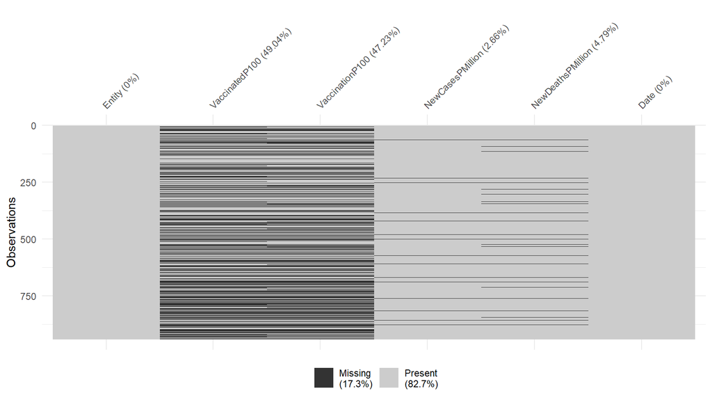

```r
#Check missings on main variables for the last 5 days
vac_miss<-all %>%
  select(VaccinatedP100,VaccinationP100,
         NewCasesPMillion=new_cases_per_million,
         NewDeathsPMillion=new_deaths_per_million,
         Date,Entity) %>%
  filter(between(Date,
                 (max(Date)-5),
                 #give one day grace period, so we don't overestimate missing
                 (max(Date)-1))) %>%
  complete(Date,Entity)

#Change column sequence so variable names and missing proportion can show completely in vis_miss graph
vac_miss<-vac_miss[, c(2,3,4,5,6,1)]
#Visualization of missing in the past 5 days
vac_miss%>%
  vis_miss()
```

```r
ggsave("Graphs/MissingBeforeImputation.PNG",width=9,height=5.06,dpi=300,limitsize=FALSE)
```

Vaccine data is more complete in terms of **Total Vaccines Doses** than in **People Vaccinated**. Therefore, the former will be used in this analysis.

In the following sections, I will first discuss the strategies that can be used to work with these missing values, then implement the strategies chosen.

# 4 Possible Strategies

## 4.1 Handeling of missing values: For entities with no vaccine data at all

If an entity has no vaccine data at all till the date of this report, it is likely that vaccine rollout has not started there. The missing values will therefore be replaced by 0. (Please see section 4.1 for a brief description of these entities, and Appendix 1 for a more detailed discussion and analysis)

## 4.2 Handling of missing values: For entities with some vaccine data

# 5 Implement the Strategy Chosen

## 5.1 Entities with no vaccination data to date

```r
#Find entities with no vaccination data till today
NoVaccine<-all %>%
  group_by(Entity) %>%
  summarize(VacValues=sum(!is.na(VaccinationP100))) %>%
  arrange(VacValues) %>%
  filter(VacValues==0)

#For these entities, replace all Vaccination values with 0
NoVaccineImputed <- all %>%
  filter(Entity %in% NoVaccine$Entity) %>%
  mutate(VaccinationP100 = replace_na(VaccinationP100,0))

#Replacing the observations in the dataset and rename the dataset Vac
Vac <- all %>%
  filter(!Entity %in% NoVaccine$Entity) %>%
  rbind(NoVaccineImputed)
```

Till the date of this report (i.e., 2021-06-20), there are **6 entities in the data that has no vaccine numbers** reported at all. It is conceivable to infer that vaccine rollout hasn’t started in these entities. Their vaccine numbers are all replaced with 0. Analysis was conducted to see whether these entities were less motivated (i.e., has less cases) or lack resources (i.e., has lower GDP per capita) to administer Covid-19 vaccines. Please see **Appendix 1** for details.

## 5.2 Drop missings before the 1st day of vaccine rollout

The starting date of vaccine rollout differs from entities to entities. In the following table, please see the entities ranked by their Vaccine Start Date.

```r
#Identity all entities that have started vaccination, then get their Day1 of vaccine rollout
Vac_Day<-Vac %>%
  group_by(Entity) %>%
  filter(VaccinationP100>0) %>%
  mutate(VacDay=1+Date-min(Date)) %>%
  ungroup()

#Put all the Day1 in a table for review
Starter <- Vac_Day %>%
  filter(VacDay==1) %>%
  select(Entity,Date) %>%
  arrange(Date) %>%
  rename(`Vaccine Start Date`=Date)
#Create the searchable, sortable table for review
datatable(Starter, options = list(
  searching = TRUE,
  columnDefs = list(list(className = 'dt-center',targets=1:2)),
               pageLength = 10)
)
```

|  | Entity | Vaccine Start Date |
| --- | --- | --- |
| 1 | China | 2020-12-15 |
| 2 | Russia | 2020-12-15 |
| 3 | Canada | 2020-12-16 |
| 4 | Israel | 2020-12-20 |
| 5 | USA | 2020-12-20 |
| 6 | Bahrain | 2020-12-23 |
| 7 | Chile | 2020-12-25 |
| 8 | Austria | 2020-12-27 |
| 9 | Czechia | 2020-12-27 |
| 10 | Denmark | 2020-12-27 |

[output cut: 175 more lines]

For each entity, only observations from the 1st day of known vaccine values were included in the analysis.

```r
#Only work on data after the first date of Vaccine rollout worldwide
Vac <- Vac %>%
  filter(Date>=min(Vac_Day$Date))

#Start Date of Each Entity
Vac_Zero <- Vac_Day %>%
  filter(VacDay==1) %>%
  select(Entity,Date) %>%
  mutate(VaccineStartDate=Date) %>%
  select(Entity,VaccineStartDate)

#For each entity, on select observations since Day1 of vaccine rollout
Vac <-Vac %>%
  #Only work with data after the first date of Vaccine rollout worldwide
  filter(Date>=min(Vac_Day$Date)) %>%
  #make sure each entity has complete dates
  complete(Entity,Date) %>%
  left_join(Vac_Zero) %>%
  group_by(Entity) %>%
  #choose observations from Day1 of vaccine rollout
  filter(Date>=VaccineStartDate) %>%
  ############mutate(VaccinationP100=if_else(Date<VaccineStartDate,0,VaccinationP100)) %>% Delete Later??
  ungroup()
```

## 5.3 Impute missings between the 1st and last day of known vaccine numbers

As said, the **na_interpolation** method will be used to fill in the gap between known vaccine numbers. One of the biggest concern for missing vaccine numbers in this data is the large proportion of missing for some entities. Followed please see the imputed values among **five entities with the most missing values** to the date of this report. Please note that the imputation always ends at the last known vaccine number for each entity, which may be one single dot at the end of the line and is therefore hard to see. (For more discussions on the imputation methods and check imputed values side by side with the original values for all entities, please see Appendix 2)

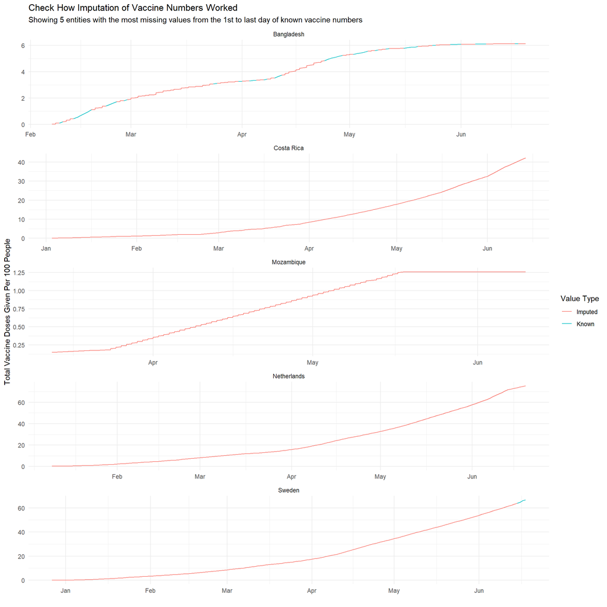

```r
#####!!!!!!!Do not change Vac file from this point on, because it is used in Appendix 2!!!!!!!
#####in the appendix, Vac is used to show what happens when imputation is used beyond the last known values######

#Identify the last day of known vaccine values for each entity
Vac_Max<-Vac %>%
  filter(VaccinationP100>0) %>%
  group_by(Entity) %>%
  summarize(VaccinationMax=max(VaccinationP100,na.rm=TRUE)) %>%
  ungroup() %>%
  select(Entity,VaccinationMax) %>%
##Identity the Last Day of Vaccine number for each entity
left_join(Vac,by=c("Entity","VaccinationMax"="VaccinationP100")) %>%
select(VacLastDate=Date,
       Entity)

#Imputation in action!
Vac_Impute<-Vac %>%
  select(Date,Entity,VaccinationP100) %>%
  left_join(Vac_Max) %>%
  group_by(Entity) %>%
  #Use the Date not the Vaccination# in filter, otherwise all gap dates will be gone.
  filter(Date<=VacLastDate) %>%
  na_interpolation(option="linear") %>%
  left_join(Vac,by=c("Entity","Date")) %>%
  rename(VacImputed=VaccinationP100.x
         , VacKnown=VaccinationP100.y) %>%
  ungroup()

#To check how imputation works:
##Identify five entities with the most missing values from 1st to last date of known vaccine numbers
MissingMost<-Vac_Impute %>%
  group_by(Entity) %>%
  summarize(Missings=sum(is.na(VacKnown))) %>%
  arrange(-Missings) %>%
  slice_head(n=5)

#Make a plot to examine the performance of the imputation algorithm
Vac_Impute %>%
  select(Entity,Date,VacImputed,VacKnown) %>%
  pivot_longer(col=c("VacImputed","VacKnown"),
               names_to="Value Type",values_to="Vaccination",
               names_prefix="Vac") %>%
  filter(Entity %in% MissingMost$Entity) %>%
  ggplot(aes(x=Date,y=Vaccination,color=`Value Type`))+
    geom_line() +
    theme_minimal()+
    facet_wrap(~Entity,scales="free",nrow=5)+
  labs(title="Check How Imputation of Vaccine Numbers Worked"
       #,title="Check How Imputation of Vaccine Numbers Worked for Entity: Sweden"
       #,subtitle="(missings values imputed with the interpolation algorithm)"
       ,subtitle="Showing 5 entities with the most missing values from the 1st to last day of known vaccine numbers"
       ,x="", y="Total Vaccine Doses Given Per 100 People")
```

```r
ggsave(filename="Graphs/Most imputation.PNG",
       width=9,height=5.06,dpi=300,limitsize=FALSE)
```

## 5.4 Smooth fluctuations in cases and deaths

```r
#Note: While new cases/deaths need to be smoothed (people continuously infected/deceased but reporting fluctuate); fluctuations in reported vaccine numbers could be a reflection of what's actually going on? Vaccine rollout, for example, could speed up or slow down with imported supply?


##Selection of relevant variables
Vac_Final <-Vac_Impute %>%
  select(Date,Entity,Continent,VacImputed
         #Known numbers of VaccinationP100
         ,VacKnown
         #Cases & Spread
         ,new_cases_per_million
         ,new_cases
         ,total_cases
         ,reproduction_rate
         #Deaths & severity of symptoms)
         ,new_deaths_per_million
         ,new_deaths
         ,total_deaths
         ,icu_patients_per_million
         ,hosp_patients_per_million
         #Tests
         ,total_tests_per_thousand
         ,positive_rate
         ,new_tests_smoothed_per_thousand
         #Control Variables
         ,iso_code
         ,GDP_per_capita
         ,Population
         ,population_density
         ,median_age
         ,aged_65_older
         ,aged_70_older
         ,life_expectancy
         ,diabetes_prevalence
         ,cardiovasc_death_rate
         ,female_smokers
         ,male_smokers
         ,handwashing_facilities
         ,hospital_beds_per_thousand
          )

##Smoothing of relevant variables
Vac_Final<-Vac_Final %>%
  arrange(Entity) %>%
  group_by(Entity) %>%
  #use rollapply instead of rollmean to handle missing
  mutate(NewCases7D=rollapply(new_cases_per_million,width=7,mean,na.rm=TRUE,partial=TRUE)
         ,ReproductionRate7D=rollapply(reproduction_rate,width=7,mean,na.rm=TRUE,partial=TRUE)
         ,NewDeaths7D=rollapply(new_deaths_per_million,width=7,mean,na.rm=TRUE,partial=TRUE)) %>%
  ungroup()

#Are there entities with case and death number to be NA to date?
No_Cases<-Vac_Final %>%
  group_by(Entity) %>%
  summarize(Values=sum(!is.na(NewCases7D))) %>%
  arrange(Values) %>%
  filter(Values==0) %>%
  select(Entity)


#Are there entities with case and death number to be NA to date?
No_Deaths<-Vac_Final %>%
  group_by(Entity) %>%
  summarize(Values=sum(!is.na(NewDeaths7D))) %>%
  arrange(Values) %>%
  filter(Values==0) %>%
  select(Entity)
```

As to the date of this report, there are 8 entities with no case values and 10 entities with no death values for all dates since its 1st day of vaccine rollout till the last day with available vaccine numbers. These missing values are replaced with 0 (see also 4.1 for handling of vaccine numbers in the similar situation).

# 6 Overview of the Data Prepared for Modeling

## 6.1 Main Variables

After all the imputations, the missing of main variables in the project are as follows.

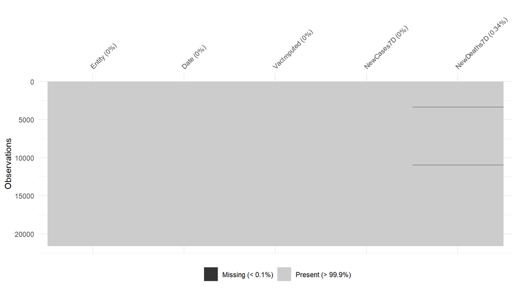

```r
#The case numbers of these entities replaced by 0
Vac_Final<-Vac_Final %>%
  group_by(Entity) %>%
  mutate(NewCases7D=if_else(Entity %in% No_Cases$Entity,
                            0,
                            NewCases7D),
         NewDeaths7D=if_else(Entity %in% No_Deaths$Entity,
                             0,
                             NewDeaths7D)) %>%
  ungroup()

##Check missings in the final data
Vac_Final %>%
  select(Entity,Date,VacImputed,NewCases7D,NewDeaths7D) %>%
  vis_miss()
```

```r
ggsave("Graphs/MissingsImputation.PNG",height=5.06,width=9,dpi=300,limitsize=FALSE)
```

## 6.2 Other Relevant Variables

Some other variables are also potentially relevant in this report. Please see followed.

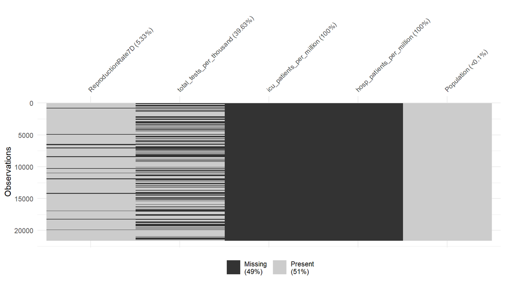

```r
Vac_Final %>%
  select(ReproductionRate7D,total_tests_per_thousand,icu_patients_per_million,hosp_patients_per_million,Population) %>%
  vis_miss()
```

```r
#save all prepared variable for other applications to analyze too, csv format
write_csv(Vac_Final,"Data/VacccineAllVariables.csv")

#Save variables needed for Shiny Dashboard, .RDS format to boost performance
shiny<-Vac_Final %>%
  select(Date, Entity, Continent, Population, VacImputed, VacKnown, NewCases7D, NewDeaths7D,
         NewCasesRaw=new_cases_per_million,
         NewDeathsRaw=new_deaths_per_million)
saveRDS(shiny,"Data/Vaccine.RDS")

#Save BasicInfo dataset (Updated Time, Doses and Population threshold)
saveRDS(BasicInfo,"Data/BasicInfo.RDS")
```

- **Test** numbers will not be included in the model because 1) there are too many missing values and 2) the missing is likely to be *systematic* rather than *random*, in that entities with less resources are more likely to be missing on these numbers.
- **Reproduction Rate** is not as complete as **Daily New Cases** (after imputation), but can still be used for reference. In the regression model estimating the effect of **Vaccination** on the **Spread** of Covid-19, **Daily New Cases** will be used as the dependent measure.
- **ICU Patients** and **Hospitalized Patients** are potentially helpful indicators for severity of symptoms. However, we lack data on these two variables. Therefore, **Deaths** will be adopted as the dependent measure in the model estimating the impact of **Vaccination** on **severity of symptoms**.
- **Population** info is relatively adequate. This variable will be used in some of the visualizations.

Other relevant variables that do not vary within each entity, such as GDP, median age, population density, will not be included in the analysis because in this analysis, I will use the **many models** method to estimate the effect of Vaccination. Specifically, the same regression model will be estimated among each and every entity, with the results then summarized in the report.

# 7 Appendix

## 7.1 Appendix 1: Explore Entities with No Vaccine Numbers to Date

At least two possible factors may contribute to the complete absence of vaccine data in these entities:

1. **Necessity**: Compare to entities with fewer cases, entities with more cases are more likely to be motivated to administer vaccine rollout and to report the progress closely.
2. **Ability**: An entity needs to have enough resources in order to administer vaccine rollout and record relevant data.

### 7.1.1 The Necessity Hypothesis: Vaccine and Total Cases

We have identified entities that have no vaccine numbers at all to date. Let’s look at their case numbers to check out the necessity hypothesis. Because entities differ in how frequently vaccine data is updated, compassion within the last five days were shown to help us get a more comprehensive picture.

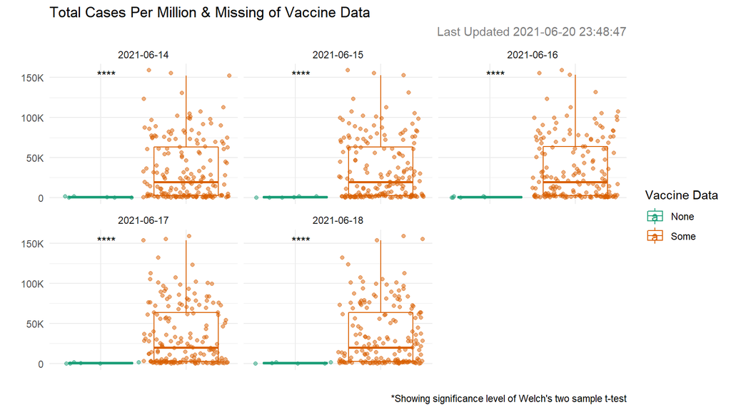

```r
library(ggpubr)

all %>%
  #Choose a specific day for comparison
  filter(Date>=(max(Date)-5),
         Date<=(max(Date)-1)) %>%
  mutate(VaccineData=if_else(Entity %in% NoVaccine$Entity, "None","Some")) %>%
  ggplot(aes(x=VaccineData,y=total_cases_per_million,color=VaccineData))+
  geom_boxplot(outlier.alpha=0)+
  geom_jitter(alpha=0.5,
              width=0.5,
              height=0.1)+
  facet_wrap(~Date,nrow=2)+
  scale_color_brewer("Vaccine Data",
                     #,labels=c("Available","Missing")
                     palette="Dark2")+
  stat_compare_means(method = "t.test", vjust=1,
                     label = "p.signif"
                     #not sure why this didn't work: check later
                     #symnum.args = list(cutpoints = c(0, 0.0001, 0.001, 0.01, 0.05,0.01, 1), symbols = c("p<0.0001", "p<0.001", "p<0.01", "p<0.05","p<0.1", "ns"))
                     )+
  theme_minimal()+
  scale_y_continuous(labels=label_number_si(accuracy=1))+
  labs(title="Total Cases Per Million & Missing of Vaccine Data",
       subtitle=Subtitle,
       x=" ",
       y=" ",
       caption="*Showing significance level of Welch's two sample t-test")+
  theme(axis.text.x=element_blank(),
        plot.subtitle=element_text(hjust=1,color="grey50"))
```

```r
ggsave("Graphs/Cases in entities with no vaccine data.PNG",height=5.06,width=9,dpi=300,limitsize=FALSE)
```

Consistent with the above discussion, entities with no vaccine data have much less confirmed cases per capita. This result, however, may need to be viewed in terms of these entities’ ability to perform tests to identify cases if there are any, which then bring us to the next section.

### 7.1.2 The Ability Hypothesis: Vaccines and GDP

Also consistent with the above discussion, entities with no vaccine data have lower GDP per capita. It is possible that lack of resources may also contribute to fewer tests, hence the lower case numbers.

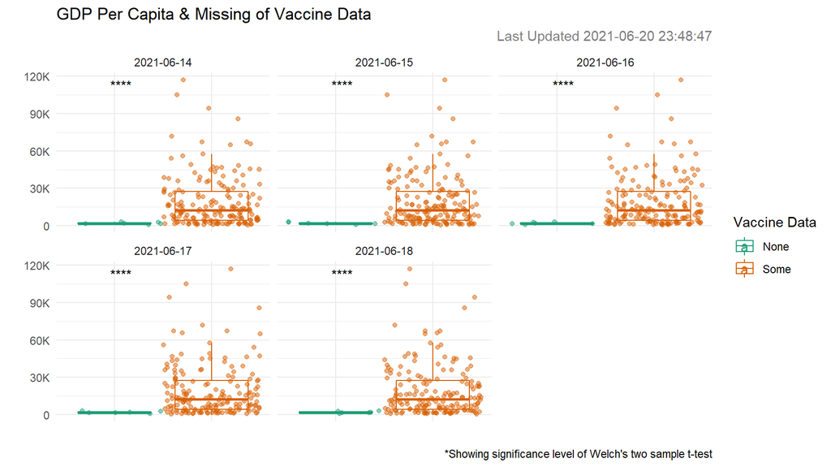

```r
#GDP and Missing on Vaccine
all %>%
  #Choose a specific day for comparison
  filter(Date>=(max(Date)-5),
         Date<=(max(Date)-1)) %>%
  mutate(VaccineData=if_else(Entity %in% NoVaccine$Entity, "None","Some")) %>%
  ggplot(aes(x=VaccineData,y=GDP_per_capita,color=VaccineData))+
  geom_boxplot(outlier.alpha=0)+
  geom_jitter(alpha=0.5,
              width=0.5,
              height=0.1)+
  facet_wrap(~Date,nrow=2)+
  scale_color_brewer("Vaccine Data",
                     palette="Dark2")+
  stat_compare_means(method = "t.test",vjust=1,
                     #show significance level
                     aes(label = ..p.signif..))+
  theme_minimal()+
  scale_y_continuous(labels=label_number_si(accuracy=1))+
  labs(title="GDP Per Capita & Missing of Vaccine Data",
       subtitle=Subtitle,
       x=" ",
       y=" ",
       caption="*Showing significance level of Welch's two sample t-test")+
  theme(axis.text.x=element_blank(),
        plot.subtitle=element_text(hjust=1,color="grey50"))
```

```r
ggsave("Graphs/GDP of entities with no vaccine data.PNG",height=5.06,width=9,dpi=300,limitsize=FALSE)
```

### 7.1.3 Location of the Entities

Finally, we can also locate these entities on the map. One may even infer the actual Covid-19 situations in these entities by looking at their neighbors. (Tempting as it is to continue with this line of analysis, I’d better leave it here as the assignment will be due in 2 days and I have only finished its section 2 about preparing the data :P)

```r
library(rworldmap)

Vac_Drop_Review <- all %>%
  mutate(VaccineData=if_else(Entity %in% NoVaccine$Entity, "None","Some")) %>%
  #choose key variables for comparison
  select(VaccineData,Entity,iso_code)

joinData <- joinCountryData2Map( Vac_Drop_Review,
                                 joinCode = "ISO3",
                                 nameJoinColumn = "iso_code")
```

```
## 85350 codes from your data successfully matched countries in the map
## 977 codes from your data failed to match with a country code in the map
## 54 codes from the map weren't represented in your data
```

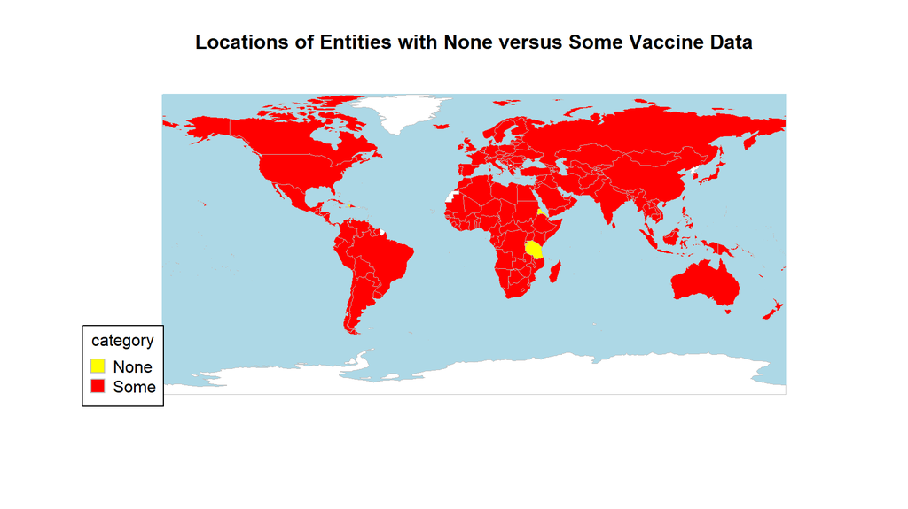

```r
#highlight entities dropped

mapParams <- mapCountryData( joinData
                                  , mapTitle="Locations of Entities with None versus Some Vaccine Data"
                                  , nameColumnToPlot="VaccineData"
                                  , addLegend=TRUE
                                  , missingCountryCol="white"
                                  , oceanCol="lightblue")
```

## 7.2 Appendix 2. Discussions on the Imputation Methods

As discussed above, the imputation method used in this project was **na_interpolation** in the **imputeTS** package. The following graph shows that although the gaps between known vaccine numbers were filled in smoothly, the values for a few days after the last known value dropped dramatically. This is understandable because na_interpolation is an imputation rather than a forecasting method. Therefore, the imputation of missing values in this analysis was done only between the 1st and last day of known vaccine numbers for each entity.

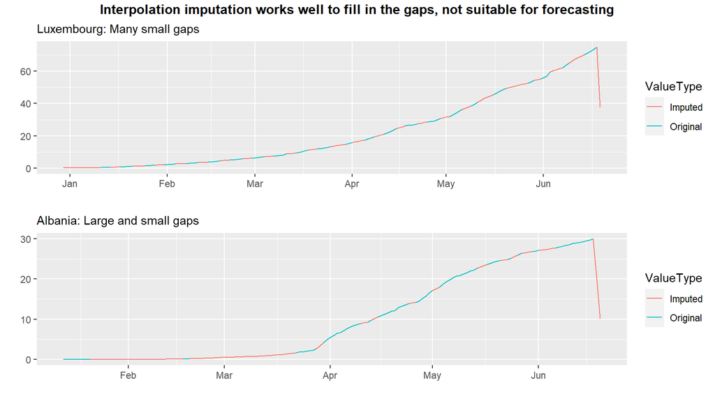

```r
Vac_impute <-Vac %>%
  select(Date,Entity,VaccinationP100) %>%
  group_by(Entity) %>%
  na_interpolation(option="linear") %>%
  left_join(Vac,by=c("Date","Entity")) %>%
  rename(Imputed=VaccinationP100.x
         , Original=VaccinationP100.y)


p1=Vac_impute %>%
  pivot_longer(col=c("Imputed","Original"),names_to="ValueType",values_to="Vaccination") %>%
  filter(Entity=="Luxembourg") %>%
  ggplot(aes(x=Date,y=Vaccination,color=ValueType))+
  geom_line()+
  labs(subtitle="Luxembourg: Many small gaps",
       x="",
       y="")
p2=Vac_impute %>%
  pivot_longer(col=c("Imputed","Original"),names_to="ValueType",values_to="Vaccination") %>%
  filter(Entity=="Albania") %>%
  ggplot(aes(x=Date,y=Vaccination,color=ValueType))+
  geom_line()+
  labs(subtitle="Albania: Large and small gaps",
       x="",
       y="")
gridExtra::grid.arrange(p1,p2
                        ,nrow=2
                        ,top = textGrob("Interpolation imputation works well to fill in the gaps, not suitable for forecasting",
                                                    gp = gpar(fontsize = 12, font = 2)))
```

Also maybe of interests is the comparison between different imputation methods. Followed please see a comparison between na_ma and na_interpolation. Results from the latter can be much smoother and likely closer to how vaccine numbers would increase gradually in an entity.

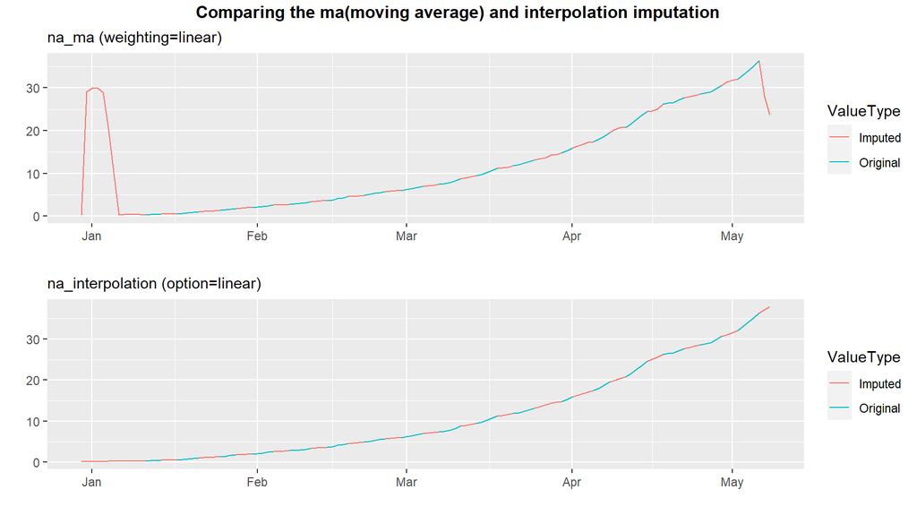

```r
##the performance of imputation algorithms differ based on data available. To demonstrate the "dip" in na_ma as compared to na_interpolation, choose a specific subset of data where it shows.
#imputation with ma (moving average)
Vac_impute_ma <-Vac %>%
  filter(Date<="2021-05-08") %>%
  select(Date,Entity,VaccinationP100) %>%
  group_by(Entity) %>%
  na_ma(k=7,weighting="linear") %>%
  left_join(Vac,by=c("Date","Entity")) %>%
  rename(Imputed=VaccinationP100.x
         , Original=VaccinationP100.y)

#Choose an entity for demonstration
#Graph 1: Performance of ma imputation
p3=Vac_impute_ma %>%
  pivot_longer(col=c("Imputed","Original"),names_to="ValueType",values_to="Vaccination") %>%
  filter(Entity=="Luxembourg") %>%
  ggplot(aes(x=Date,y=Vaccination,color=ValueType))+
  geom_line()+
  labs(subtitle="na_ma (weighting=linear)",
       x="",
       y="")
#Graph 2: Performance of interpolation imputation
p4=Vac_impute %>%
  filter(Date<="2021-05-08") %>%
  pivot_longer(col=c("Imputed","Original"),names_to="ValueType",values_to="Vaccination") %>%
  filter(Entity=="Luxembourg") %>%
  ggplot(aes(x=Date,y=Vaccination,color=ValueType))+
  geom_line()+
  labs(subtitle="na_interpolation (option=linear)",
       x="",
       y="")

gridExtra::grid.arrange(p3,p4
                        ,nrow=2
                        ,top = textGrob("Comparing the ma(moving average) and interpolation imputation",
                                                    gp = gpar(fontsize = 12, font = 2))
                        )
```

The above graph is based on data of Luxembourg. In the following data, you can check and compare the performance of these two imputation methods for data of all entities of interests.

```r
CheckImputation<-Vac_impute %>%
  select(Entity,Date,Original,InterpolationImputed=Imputed) %>%
  left_join(Vac_impute_ma) %>%
  select(Entity,Date,Original,InterpolationImputed,MaImputed=Imputed)

datatable(CheckImputation)
```

|  | Entity | Date | Original | InterpolationImputed | MaImputed |
| --- | --- | --- | --- | --- | --- |
| 1 | Afghanistan | 2021-02-28 | 0.02 | 0.02 | 0.02 |
| 2 | Afghanistan | 2021-03-01 |  | 0.0275 | 0.0333333333333333 |
| 3 | Afghanistan | 2021-03-02 |  | 0.035 | 0.04 |
| 4 | Afghanistan | 2021-03-03 |  | 0.0425 | 0.0466666666666667 |
| 5 | Afghanistan | 2021-03-04 |  | 0.05 | 0.0533333333333333 |
| 6 | Afghanistan | 2021-03-05 |  | 0.0575 | 0.06 |
| 7 | Afghanistan | 2021-03-06 |  | 0.065 | 0.0666666666666667 |
| 8 | Afghanistan | 2021-03-07 |  | 0.0725 | 0.0733333333333333 |
| 9 | Afghanistan | 2021-03-08 |  | 0.08 | 0.08 |
| 10 | Afghanistan | 2021-03-09 |  | 0.0875 | 0.0866666666666667 |

[output cut: 21470 more lines]

## 7.3 Appendix 3. Missing on Potential Control Variables

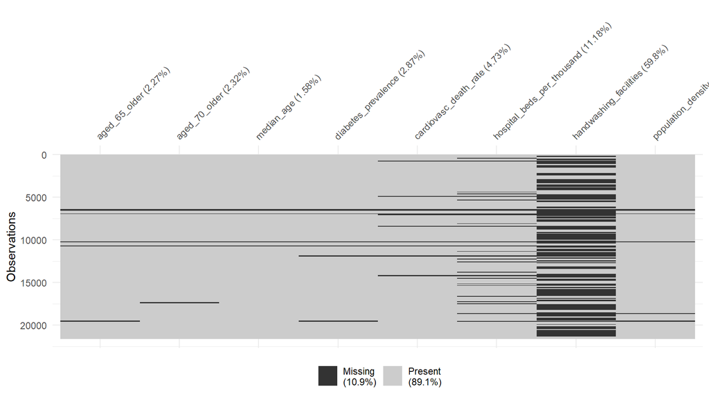

```r
Vac_Final %>%
  select(aged_65_older,aged_70_older,median_age,diabetes_prevalence,cardiovasc_death_rate,hospital_beds_per_thousand,handwashing_facilities,population_density) %>%
  vis_miss()
```